# Informe 5: Modelos de Agrupamiento

- **Asignatura:** Inteligencia Artificial
- **Grupo:** 03
- **Integrantes:** Bautista De la Cruz Claudia Daniela, Carrascal Castro Priscila Maria, Ccahuana Quiñones Judith Valeria, Gil Sixi Alberto Luis, Medrano Ayma Nikol Arlet, Rosales Trinidad Jeanmarco Miguel, Saire Tello Fernando José

## Empresa: AndinaSense

AndinaSense es una empresa de agricultura de precisión que brinda servicios de monitoreo a agroexportadoras de arándano en los valles de la costa norte del Perú (La Libertad, Lambayeque e Ica). Mediante sensores instalados en las parcelas, registra las condiciones de suelo, clima y manejo de cada una. Con miles de parcelas bajo monitoreo, necesita agruparlas en perfiles que permitan un manejo diferenciado y eficiente, en lugar de tratarlas todas por igual.

### Planteamiento del informe

**Objetivo del informe:** Segmentar las parcelas de arándano en grupos según sus condiciones de suelo, clima y manejo, usando aprendizaje no supervisado (K-Means y DBSCAN), para identificar perfiles de parcela y detectar parcelas atípicas.

**Pregunta de negocio:** ¿Qué tipos de parcela existen según sus condiciones, y cuáles se apartan del patrón habitual?

**Por qué aporta valor:** Conocer estos perfiles permitirá a AndinaSense dar un manejo diferenciado a cada tipo de parcela (riego, pH, fertilización) y revisar a tiempo las parcelas atípicas. A diferencia de los informes de regresión y clasificación, aquí el modelo no usa las variables de resultado (rendimiento o calidad): agrupa únicamente a partir de las condiciones medidas por los sensores.

## Generación y carga del dataset

El dataset `andinasense_parcelas.csv` es sintético y propio del grupo. Contiene 1500 parcelas (filas) y 13 variables (columnas), con mezcla de numéricas y categóricas. La variable objetivo continua es `rendimiento_kg_ha` y la categórica es `calidad_cosecha` (Baja, Media, Alta).

Generación (reproducible con semilla SEED = 42):

- Las parcelas provienen de 4 zonas agroecológicas latentes con proporciones controladas (Óptima 35%, Estrés Hídrico 25%, Desbalance de pH 20%, Multi-estrés Leve 20%). La zona se usa solo para generar y no aparece como columna.
- Cada zona tiene un perfil de medias por variable de suelo, clima y manejo, con dispersión calibrada para un solapamiento realista (correlaciones y ruido, no grupos perfectos).
- `rendimiento_kg_ha` se deriva de una función de respuesta agronómica con penalización cuadrática (óptimo de temperatura 20 °C y de pH 5.5) más ruido gaussiano; `calidad_cosecha` se obtiene por terciles del rendimiento.
- Se introdujeron nulos y valores atípicos intencionales en las columnas de sensores para exigir tratamiento en el preprocesamiento.

El script generador completo, reproducible con la misma semilla, está en el repositorio del proyecto (carpeta `generador_dataset`). Este notebook no regenera los datos: solo carga el CSV en la siguiente celda.

## 1. Importar librerías y cargar los datos

```python
# Evitar el warning de KMeans en Windows (MKL)
import os
os.environ['OMP_NUM_THREADS'] = '6'

# Librerías base
import numpy as np
import pandas as pd
import matplotlib.pyplot as plt
import seaborn as sns

# Preprocesamiento
from sklearn.impute import SimpleImputer
from sklearn.preprocessing import StandardScaler
from sklearn.pipeline import Pipeline

# Algoritmos de agrupamiento
from sklearn.cluster import KMeans, DBSCAN, HDBSCAN
from sklearn.neighbors import NearestNeighbors

# Métricas de evaluación no supervisada
from sklearn.metrics import (silhouette_score, silhouette_samples,
                             davies_bouldin_score, calinski_harabasz_score)

# Proyección para visualizar los grupos en 2D
from sklearn.decomposition import PCA

# Semilla global para reproducibilidad
SEED = 42

# Estilo de gráficos consistente y legible
sns.set_style('whitegrid')
plt.rcParams['figure.dpi'] = 120

# Cargar el dataset (debe estar en la misma carpeta que este notebook)
ARCHIVO = 'andinasense_parcelas.csv'
if not os.path.exists(ARCHIVO):
    raise FileNotFoundError(
        f"No se encontró '{ARCHIVO}'. "
        f"Coloca el CSV en la misma carpeta que este notebook y vuelve a ejecutar."
    )
df = pd.read_csv(ARCHIVO)
print('Dimensiones:', df.shape)
df.head()
```

```
Dimensiones: (1500, 13)
```

|  | id_parcela | region | variedad | superficie_ha | temp_promedio | humedad_suelo | ph_suelo | horas_sol | riego_mm | fertilizante_kg | densidad_plantas | rendimiento_kg_ha | calidad_cosecha |
| --- | --- | --- | --- | --- | --- | --- | --- | --- | --- | --- | --- | --- | --- |
| 0 | PARC-00001 | Lambayeque | Emerald | 10.55 | 19.5 | 55.5 | 6.72 | 9.6 | 523.0 | 282.0 | 4443.0 | 8476.0 | Baja |
| 1 | PARC-00002 | Lambayeque | Biloxi | 4.33 | 22.0 | 42.1 | 5.48 | 8.4 | 698.0 | 166.0 | 4204.0 | 8542.0 | Baja |
| 2 | PARC-00003 | La Libertad | Ventura | 5.04 | 21.0 | 40.7 | 6.22 | 7.7 | 619.0 | 253.0 | 3547.0 | 9270.0 | Alta |
| 3 | PARC-00004 | La Libertad | Rocio | 7.19 | 20.4 | 52.1 | 6.63 | 9.2 | 507.0 | 277.0 | 4229.0 | 8624.0 | Media |
| 4 | PARC-00005 | Lambayeque | Biloxi | 2.76 | 20.8 | 56.9 | 5.33 | 9.2 | 592.0 | 201.0 | 3778.0 | 9033.0 | Media |

## 2. Exploración de los datos para el agrupamiento

```python
# Estructura general y tipos de dato
df.info()

# Valores faltantes por columna: conteo y porcentaje
print('\nValores faltantes por columna:')
faltantes = pd.DataFrame({
    'n_nulos': df.isnull().sum(),
    'porcentaje': (df.isnull().mean() * 100).round(2)
})
print(faltantes[faltantes['n_nulos'] > 0])

# Estadísticos descriptivos de las variables numéricas
df.describe()
```

```
<class 'pandas.core.frame.DataFrame'>
RangeIndex: 1500 entries, 0 to 1499
Data columns (total 13 columns):
 #   Column             Non-Null Count  Dtype
---  ------             --------------  -----
 0   id_parcela         1500 non-null   object
 1   region             1500 non-null   object
 2   variedad           1500 non-null   object
 3   superficie_ha      1500 non-null   float64
 4   temp_promedio      1500 non-null   float64
 5   humedad_suelo      1440 non-null   float64
 6   ph_suelo           1455 non-null   float64
 7   horas_sol          1463 non-null   float64
 8   riego_mm           1500 non-null   float64
 9   fertilizante_kg    1500 non-null   float64
 10  densidad_plantas   1500 non-null   float64
 11  rendimiento_kg_ha  1500 non-null   float64
 12  calidad_cosecha    1500 non-null   object
dtypes: float64(9), object(4)
memory usage: 152.5+ KB

Valores faltantes por columna:
               n_nulos  porcentaje
humedad_suelo       60        4.00
ph_suelo            45        3.00
horas_sol           37        2.47
```

|  | superficie_ha | temp_promedio | humedad_suelo | ph_suelo | horas_sol | riego_mm | fertilizante_kg | densidad_plantas | rendimiento_kg_ha |
| --- | --- | --- | --- | --- | --- | --- | --- | --- | --- |
| count | 1500.000000 | 1500.000000 | 1440.000000 | 1455.000000 | 1463.000000 | 1500.000000 | 1500.000000 | 1500.000000 | 1500.000000 |
| mean | 7.027380 | 21.185867 | 52.310903 | 5.951677 | 8.751401 | 600.579333 | 219.987333 | 3937.514667 | 8795.932667 |
| std | 2.939367 | 1.417107 | 10.514019 | 0.649084 | 0.897387 | 73.156022 | 39.595526 | 349.173746 | 523.583496 |
| min | 2.000000 | 17.600000 | 25.300000 | 4.720000 | 5.800000 | 442.000000 | 106.000000 | 2831.000000 | 6740.000000 |
| 25% | 4.500000 | 20.100000 | 43.900000 | 5.500000 | 8.200000 | 546.000000 | 193.000000 | 3695.000000 | 8439.000000 |
| 50% | 7.035000 | 21.100000 | 53.600000 | 5.730000 | 8.900000 | 586.000000 | 218.000000 | 3954.500000 | 8832.000000 |
| 75% | 9.600000 | 22.325000 | 60.000000 | 6.300000 | 9.400000 | 653.000000 | 247.000000 | 4184.250000 | 9172.750000 |
| max | 11.990000 | 25.500000 | 120.600000 | 11.720000 | 10.900000 | 830.000000 | 362.000000 | 5059.000000 | 10131.000000 |

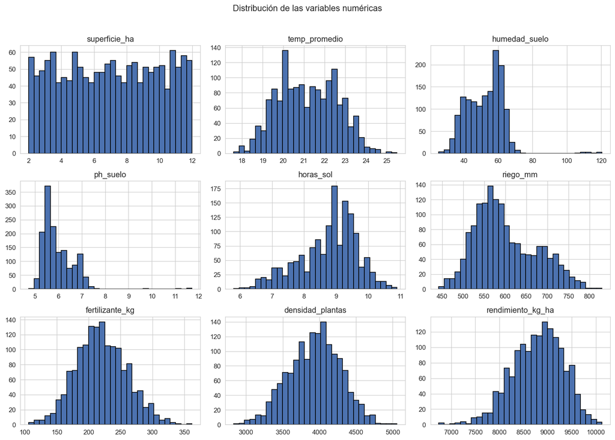

```python
# Distribución de las variables numéricas
num_cols = df.select_dtypes(include=np.number).columns
df[num_cols].hist(bins=30, figsize=(13, 9), color='#4C72B0', edgecolor='black')
plt.suptitle('Distribución de las variables numéricas', y=1.02, fontsize=13)
plt.tight_layout()
plt.show()
```

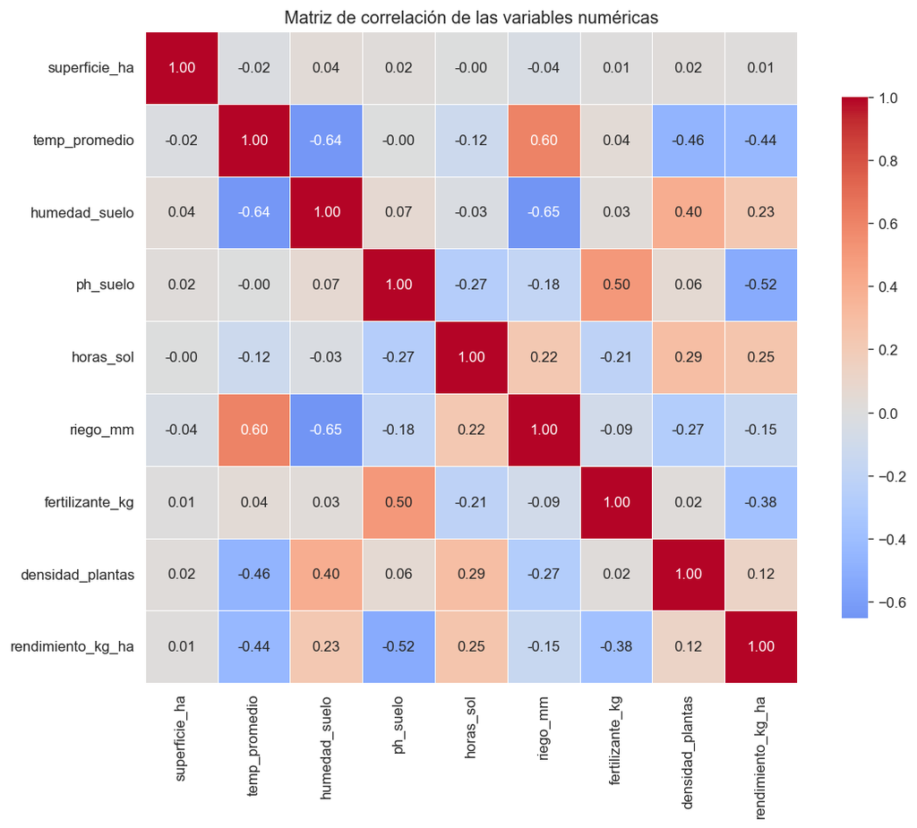

```python
# Matriz de correlación entre variables numéricas
plt.figure(figsize=(10, 8))
corr = df[num_cols].corr()
sns.heatmap(corr, annot=True, fmt='.2f', cmap='coolwarm', center=0,
            square=True, linewidths=0.5, cbar_kws={'shrink': 0.8})
plt.title('Matriz de correlación de las variables numéricas')
plt.tight_layout()
plt.show()
```

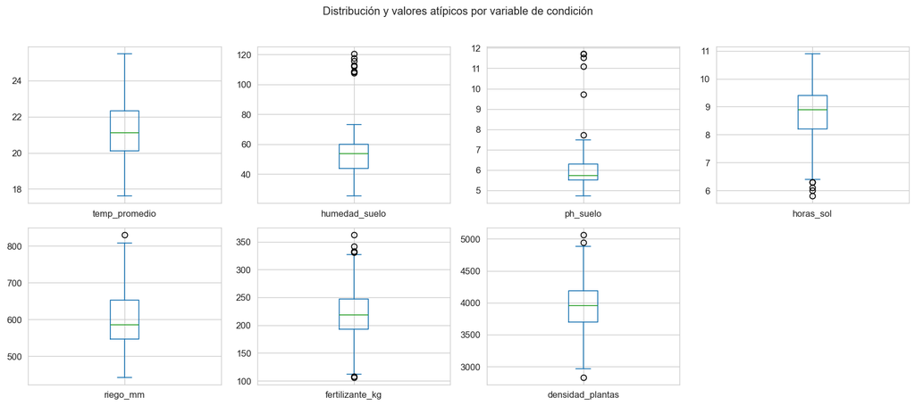

```python
# Muestra los outliers
cols_sensor = ['temp_promedio','humedad_suelo','ph_suelo','horas_sol',
               'riego_mm','fertilizante_kg','densidad_plantas']

df[cols_sensor].plot(kind='box', subplots=True, layout=(2,4),
                     figsize=(14,6), sharey=False)
plt.suptitle('Distribución y valores atípicos por variable de condición', y=1.02)
plt.tight_layout()
plt.show()
```

## 3. Corrección de valores imposibles

```python
# Se convierten los valores imposibles a NaN para imputarlos luego dentro del pipeline.
# Criterios: humedad de suelo > 100% no existe; pH de suelo agrícola realista entre 3.5 y 9.

nulos_antes = df[['humedad_suelo', 'ph_suelo']].isnull().sum()

df.loc[df['humedad_suelo'] > 100, 'humedad_suelo'] = np.nan
df.loc[(df['ph_suelo'] < 3.5) | (df['ph_suelo'] > 9), 'ph_suelo'] = np.nan

nulos_despues = df[['humedad_suelo', 'ph_suelo']].isnull().sum()

print('Valores imposibles convertidos a NaN:')
print((nulos_despues - nulos_antes))

print('\nValores faltantes por columna tras la corrección:')
faltantes = df.isnull().sum()
print(faltantes[faltantes > 0])
```

```
Valores imposibles convertidos a NaN:
humedad_suelo    8
ph_suelo         5
dtype: int64

Valores faltantes por columna tras la corrección:
humedad_suelo    68
ph_suelo         50
horas_sol        37
dtype: int64
```

## 4. Selección de variables y escalamiento

Para el agrupamiento se utilizan las **7 variables de condición** de la parcela (suelo, clima y manejo): `temp_promedio`, `humedad_suelo`, `ph_suelo`, `horas_sol`, `riego_mm`, `fertilizante_kg` y `densidad_plantas`.

Se excluyen:

- `superficie_ha`: es una variable de contexto (tamaño de la parcela), no una condición de cultivo; su histograma uniforme confirma que no aporta estructura.
- `rendimiento_kg_ha` y `calidad_cosecha`: son los resultados de la parcela (variables objetivo de los Informes 3 y 4); se reservan para perfilar los segmentos, no para formarlos.

Como el agrupamiento se basa en distancias y las variables están en escalas muy distintas, se estandarizan con `StandardScaler`. La imputación de los valores faltantes (con la mediana, robusta ante atípicos) se realiza dentro de un Pipeline junto con el escalado, encapsulando el preprocesamiento en un objeto único, reproducible y consistente.

```python
# Variables de condición seleccionadas para el agrupamiento
variables_cluster = ['temp_promedio', 'humedad_suelo', 'ph_suelo', 'horas_sol',
                     'riego_mm', 'fertilizante_kg', 'densidad_plantas']

X = df[variables_cluster].copy()

# Pipeline de preprocesamiento: imputación con mediana + estandarización
preprocesador = Pipeline(steps=[
    ('imputador', SimpleImputer(strategy='median')),
    ('escalador', StandardScaler())
])

# Ajustar y transformar
X_scaled = preprocesador.fit_transform(X)

# Transparencia: medianas usadas en la imputación
medianas = preprocesador.named_steps['imputador'].statistics_
print('Medianas usadas para imputar:')
for col, med in zip(variables_cluster, medianas):
    print(f'  {col}: {med:.2f}')

# Verificación del escalado: media ~0 y desviación ~1
print('\nMedia tras escalar (~0):', np.round(X_scaled.mean(axis=0), 2))
print('Desv. tras escalar (~1):', np.round(X_scaled.std(axis=0), 2))
```

```
Medianas usadas para imputar:
  temp_promedio: 21.10
  humedad_suelo: 53.50
  ph_suelo: 5.73
  horas_sol: 8.90
  riego_mm: 586.00
  fertilizante_kg: 218.00
  densidad_plantas: 3954.50

Media tras escalar (~0): [ 0.  0. -0.  0. -0. -0.  0.]
Desv. tras escalar (~1): [1. 1. 1. 1. 1. 1. 1.]
```

## 5. Tendencia de agrupamiento (test de Hopkins)

```python
# Antes de agrupar, verificamos si los datos tienen estructura de grupos
# o si están distribuidos al azar (en cuyo caso agrupar no tendría sentido).
def estadistico_hopkins(X, proporcion=0.1, seed=SEED):
    """
    Convención: ~0.5 = datos casi aleatorios (sin tendencia clara a agruparse);
                cerca de 1 = fuerte tendencia de agrupamiento.
    X debe estar ya escalado.
    """
    rng = np.random.RandomState(seed)
    n, d = X.shape
    m = int(proporcion * n)                       # tamaño de muestra (10%)
    vecinos = NearestNeighbors(n_neighbors=2).fit(X)

    # distancia de puntos REALES a su vecino real más cercano
    idx = rng.choice(n, m, replace=False)
    dist_reales = vecinos.kneighbors(X[idx], 2, return_distance=True)[0][:, 1]

    # distancia de puntos ALEATORIOS uniformes al punto real más cercano
    minimos, maximos = X.min(axis=0), X.max(axis=0)
    aleatorios = rng.uniform(minimos, maximos, (m, d))
    dist_aleatorias = vecinos.kneighbors(aleatorios, 1, return_distance=True)[0][:, 0]

    return dist_aleatorias.sum() / (dist_reales.sum() + dist_aleatorias.sum())

H = estadistico_hopkins(X_scaled)
print(f'Estadístico de Hopkins: {H:.3f}')

if H < 0.55:
    print('-> Cerca de 0.5: los datos NO muestran tendencia clara a agruparse.')
elif H < 0.75:
    print(f'-> {H:.2f}: hay densidad y estructura, pero conviene confirmar')
    print('   con la silueta que sean grupos separables y no una sola nube.')
else:
    print(f'-> {H:.2f}: fuerte tendencia de agrupamiento; procede aplicar clustering.')
```

```
Estadístico de Hopkins: 0.759
-> 0.76: fuerte tendencia de agrupamiento; procede aplicar clustering.
```

## 6. Número óptimo de clústeres para K-Means

```python
# Se prueba K-Means para distintos valores de k y se calculan cuatro métricas internas:
# inercia (codo), coeficiente de silueta, índice Davies-Bouldin e índice Calinski-Harabasz.
rango_k = range(2, 11)
inercias, siluetas, davies_bouldin, calinski = [], [], [], []

for k in rango_k:
    km = KMeans(n_clusters=k, n_init=10, random_state=SEED)
    etiquetas = km.fit_predict(X_scaled)
    inercias.append(km.inertia_)
    siluetas.append(silhouette_score(X_scaled, etiquetas))
    davies_bouldin.append(davies_bouldin_score(X_scaled, etiquetas))
    calinski.append(calinski_harabasz_score(X_scaled, etiquetas))

# Tabla resumen de las cuatro métricas por k
resumen = pd.DataFrame({
    'k': list(rango_k),
    'inercia': np.round(inercias, 1),
    'silueta': np.round(siluetas, 4),
    'davies_bouldin': np.round(davies_bouldin, 4),
    'calinski_harabasz': np.round(calinski, 1)
})
print(resumen.to_string(index=False))

# k óptimo según cada métrica (triangulación)
print('\nMejor silueta -> k =', int(resumen.loc[resumen.silueta.idxmax(), 'k']))
print('Menor Davies-Bouldin -> k =', int(resumen.loc[resumen.davies_bouldin.idxmin(), 'k']))
print('Mayor Calinski-Harabasz -> k =', int(resumen.loc[resumen.calinski_harabasz.idxmax(), 'k']))
```

```
 k  inercia  silueta  davies_bouldin  calinski_harabasz
 2   7159.2   0.3075          1.4150              699.0
 3   5384.3   0.3395          1.2524              711.2
 4   3771.8   0.3999          0.9804              889.5
 5   3555.8   0.3019          1.4583              729.9
 6   3389.4   0.2361          1.7560              626.8
 7   3266.3   0.1840          1.9994              551.1
 8   3141.9   0.1780          1.9250              499.2
 9   3032.7   0.1415          2.0931              458.9
10   2963.1   0.1355          2.1143              421.1

Mejor silueta -> k = 4
Menor Davies-Bouldin -> k = 4
Mayor Calinski-Harabasz -> k = 4
```

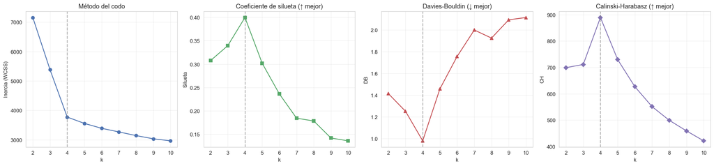

```python
fig, axes = plt.subplots(1, 4, figsize=(19, 4.5))
ax1, ax2, ax3, ax4 = axes

ax1.plot(list(rango_k), inercias, 'o-', color='#4C72B0')
ax1.set_title('Método del codo'); ax1.set_xlabel('k'); ax1.set_ylabel('Inercia (WCSS)')
ax1.grid(alpha=0.3)

ax2.plot(list(rango_k), siluetas, 's-', color='#55A868')
ax2.set_title('Coeficiente de silueta (↑ mejor)'); ax2.set_xlabel('k'); ax2.set_ylabel('Silueta')
ax2.grid(alpha=0.3)

ax3.plot(list(rango_k), davies_bouldin, '^-', color='#C44E52')
ax3.set_title('Davies-Bouldin (↓ mejor)'); ax3.set_xlabel('k'); ax3.set_ylabel('DB')
ax3.grid(alpha=0.3)

ax4.plot(list(rango_k), calinski, 'D-', color='#8172B3')
ax4.set_title('Calinski-Harabasz (↑ mejor)'); ax4.set_xlabel('k'); ax4.set_ylabel('CH')
ax4.grid(alpha=0.3)

# Marcar k=4 en los cuatro paneles
for ax in axes:
    ax.axvline(4, color='gray', ls='--', alpha=0.6)

plt.tight_layout()
plt.savefig('seleccion_k.png', dpi=150, bbox_inches='tight')
plt.show()
```

## 7. Modelo K-means definitivo

```python
k_optimo = 4

kmeans = KMeans(n_clusters=k_optimo, n_init=10, random_state=SEED)
df['cluster_kmeans'] = kmeans.fit_predict(X_scaled)

# Cuántas parcelas hay por grupo
print(df['cluster_kmeans'].value_counts().sort_index())

# Perfil promedio de cada grupo en las unidades ORIGINALES (las 7 variables de condición)
perfil = df.groupby('cluster_kmeans')[variables_cluster].mean().round(1)
perfil
```

```
cluster_kmeans
0    535
1    307
2    381
3    277
Name: count, dtype: int64
```

| cluster_kmeans | temp_promedio | humedad_suelo | ph_suelo | horas_sol | riego_mm | fertilizante_kg | densidad_plantas |
| --- | --- | --- | --- | --- | --- | --- | --- |
| 0 | 20.0 | 60.1 | 5.5 | 9.0 | 551.2 | 198.0 | 4090.9 |
| 1 | 22.2 | 47.6 | 6.2 | 7.4 | 598.2 | 234.8 | 3545.5 |
| 2 | 22.6 | 39.8 | 5.6 | 9.5 | 700.9 | 206.9 | 3835.5 |
| 3 | 20.5 | 58.0 | 6.9 | 8.8 | 560.6 | 264.1 | 4216.1 |

## 8. DBSCAN

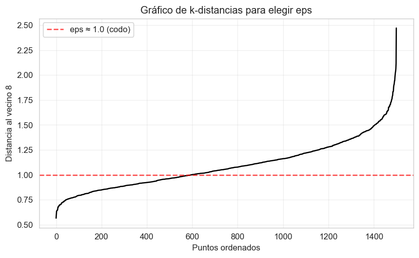

```python
# DBSCAN necesita eps (radio) y min_samples. Para elegir eps, graficamos la
# distancia de cada punto a su k-ésimo vecino, ordenada, y buscamos el "codo".
min_samples = 8
vecinos = NearestNeighbors(n_neighbors=min_samples).fit(X_scaled)
distancias, _ = vecinos.kneighbors(X_scaled)
k_dist = np.sort(distancias[:, min_samples - 1])

plt.figure(figsize=(8, 4.5))
plt.plot(k_dist, color='black')
plt.axhline(1.0, color='red', ls='--', alpha=0.7, label='eps ≈ 1.0 (codo)')
plt.xlabel('Puntos ordenados'); plt.ylabel(f'Distancia al vecino {min_samples}')
plt.title('Gráfico de k-distancias para elegir eps')
plt.legend(); plt.grid(alpha=0.3); plt.show()
```

```python
# Entrenar DBSCAN con el eps del codo (~1.0)
for eps in [1.0, 1.2]:
    dbscan = DBSCAN(eps=eps, min_samples=min_samples)
    etiquetas_db = dbscan.fit_predict(X_scaled)
    n_clusters = len(set(etiquetas_db)) - (1 if -1 in etiquetas_db else 0)
    n_ruido = (etiquetas_db == -1).sum()
    print(f'eps={eps}: {n_clusters} clústeres | ruido = {n_ruido} '
          f'({n_ruido/len(etiquetas_db)*100:.1f}%)')

# Modelo DBSCAN elegido (eps=1.0) y guardado de etiquetas
dbscan = DBSCAN(eps=1.0, min_samples=min_samples)
df['cluster_dbscan'] = dbscan.fit_predict(X_scaled)
print('\nDistribución final DBSCAN (eps=1.0):')
print(df['cluster_dbscan'].value_counts().sort_index())
```

```
eps=1.0: 4 clústeres | ruido = 451 (30.1%)
eps=1.2: 3 clústeres | ruido = 106 (7.1%)

Distribución final DBSCAN (eps=1.0):
cluster_dbscan
-1    451
 0    170
 1    424
 2    195
 3    260
Name: count, dtype: int64
```

## 9. Visualizar y comparar K-means vs DBSCAN

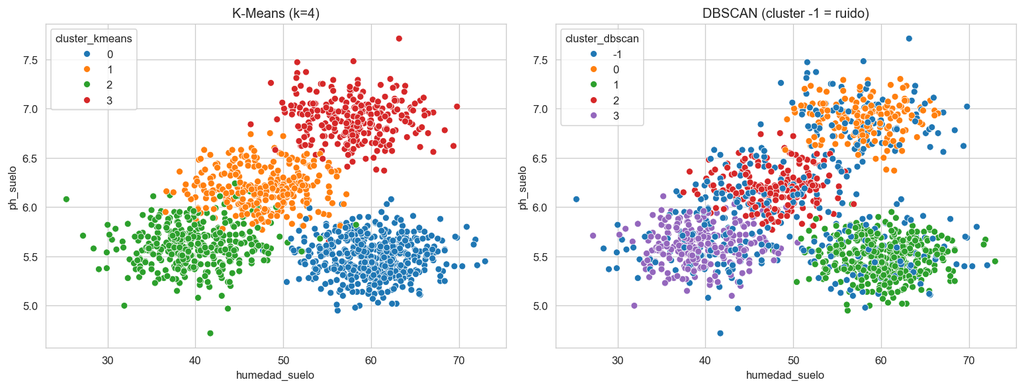

```python
# ── Visualización comparativa: K-means vs DBSCAN sobre dos variables ──
# Proyectamos los grupos sobre humedad_suelo y ph_suelo (dos variables que
# separan bien los tipos de parcela) para comparar visualmente cómo agrupa
# cada algoritmo. En DBSCAN, el clúster -1 corresponde al ruido.
fig, axes = plt.subplots(1, 2, figsize=(13, 5))

sns.scatterplot(data=df, x='humedad_suelo', y='ph_suelo',
                hue='cluster_kmeans', palette='tab10', ax=axes[0], legend='full')
axes[0].set_title('K-Means (k=4)')

sns.scatterplot(data=df, x='humedad_suelo', y='ph_suelo',
                hue='cluster_dbscan', palette='tab10', ax=axes[1], legend='full')
axes[1].set_title('DBSCAN (cluster -1 = ruido)')

plt.tight_layout(); plt.show()
```

### Comparación visual K-means vs DBSCAN

- K-means separa los cuatro tipos con claridad incluso en solo 2 de las 7 variables: humedad baja/pH bajo, humedad alta/pH bajo, pH alto, e intermedio.
- En DBSCAN, el ruido (-1) se concentra en los bordes y zonas de transición entre grupos: son las parcelas intermedias que no caen en ningún núcleo denso.
- Esto explica visualmente por qué DBSCAN descarta ~30%: pierde justamente las parcelas de frontera, que K-means sí clasifica.

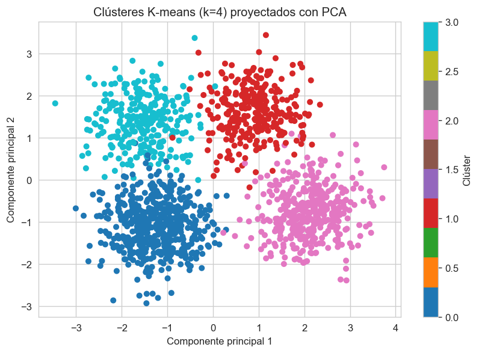

```python
# ── Visualización de los clústeres con PCA ──
# Proyectamos las 7 variables a 2 componentes para visualizar los grupos.
coords = PCA(n_components=2, random_state=SEED).fit_transform(X_scaled)

plt.figure(figsize=(7, 5))
dispersion = plt.scatter(coords[:, 0], coords[:, 1],
                         c=df['cluster_kmeans'], cmap='tab10', s=25)
plt.xlabel('Componente principal 1')
plt.ylabel('Componente principal 2')
plt.title('Clústeres K-means (k=4) proyectados con PCA')
plt.colorbar(dispersion, label='Clúster')
plt.tight_layout()
plt.show()
```

## 10. Perfilar e interpretar los segmentos

```python
# Traducimos los perfiles numéricos a tipos de parcela con acción agronómica.
perfil = df.groupby('cluster_kmeans')[variables_cluster].mean().round(1)
perfil['n_parcelas'] = df['cluster_kmeans'].value_counts().sort_index()
perfil
```

| cluster_kmeans | temp_promedio | humedad_suelo | ph_suelo | horas_sol | riego_mm | fertilizante_kg | densidad_plantas | n_parcelas |
| --- | --- | --- | --- | --- | --- | --- | --- | --- |
| 0 | 20.0 | 60.1 | 5.5 | 9.0 | 551.2 | 198.0 | 4090.9 | 535 |
| 1 | 22.2 | 47.6 | 6.2 | 7.4 | 598.2 | 234.8 | 3545.5 | 307 |
| 2 | 22.6 | 39.8 | 5.6 | 9.5 | 700.9 | 206.9 | 3835.5 | 381 |
| 3 | 20.5 | 58.0 | 6.9 | 8.8 | 560.6 | 264.1 | 4216.1 | 277 |

### Perfilamiento e interpretación de negocio

Cada grupo de K-means corresponde a un tipo de parcela con una condición predominante, lo que habilita un manejo agronómico diferenciado:

| Grupo | Perfil característico | Nombre | Acción agronómica |
| --- | --- | --- | --- |
| 0 | humedad ~60%, pH ~5.5, temp ~20°C | Parcelas Óptimas | Mantener manejo; monitoreo estándar |
| 1 | humedad ~48%, pH ~6.2, menos sol | Multi-estrés Leve | Diagnóstico integral; intervención combinada |
| 2 | humedad ~40%, riego alto | Estrés Hídrico | Revisar riego y retención de agua |
| 3 | pH ~6.9, más fertilización | Desbalance de pH | Acidificar el suelo (azufre) |

El valor del agrupamiento está aquí: cada tipo dispara una acción distinta. Tratar todas las parcelas por igual desperdiciaría recursos; segmentarlas permite dirigir cada intervención donde hace falta, reduciendo costos y pérdidas.

## 11. Comparación de algoritmos (triangulación de métricas)

```python
# Nota: en DBSCAN y HDBSCAN se excluyen los puntos de ruido (-1) al calcular las métricas.
def evaluar_modelo(nombre, etiquetas):
    mascara = etiquetas != -1
    n_clusters = len(set(etiquetas[mascara]))
    ruido = (etiquetas == -1).mean() * 100
    return {
        'Modelo': nombre,
        'N_clústeres': n_clusters,
        'Silueta': round(silhouette_score(X_scaled[mascara], etiquetas[mascara]), 3),
        'Davies-Bouldin': round(davies_bouldin_score(X_scaled[mascara], etiquetas[mascara]), 3),
        'Calinski-Harabasz': round(calinski_harabasz_score(X_scaled[mascara], etiquetas[mascara]), 1),
        '% Ruido': round(ruido, 1)
    }

km_lab = KMeans(n_clusters=4, n_init=10, random_state=SEED).fit_predict(X_scaled)
db_lab = DBSCAN(eps=1.0, min_samples=8).fit_predict(X_scaled)
hd_lab = HDBSCAN(min_cluster_size=50).fit_predict(X_scaled)

comparacion = pd.DataFrame([
    evaluar_modelo('K-means (k=4)', km_lab),
    evaluar_modelo('DBSCAN (eps=1.0)', db_lab),
    evaluar_modelo('HDBSCAN (mcs=50)', hd_lab),
])
comparacion
```

|  | Modelo | N_clústeres | Silueta | Davies-Bouldin | Calinski-Harabasz | % Ruido |
| --- | --- | --- | --- | --- | --- | --- |
| 0 | K-means (k=4) | 4 | 0.400 | 0.980 | 889.5 | 0.0 |
| 1 | DBSCAN (eps=1.0) | 4 | 0.466 | 0.827 | 847.0 | 30.1 |
| 2 | HDBSCAN (mcs=50) | 4 | 0.508 | 0.722 | 707.3 | 51.3 |

## Conclusiones

- **El test de Hopkins (0.76)** indicó tendencia al agrupamiento, y las cuatro métricas internas (codo, silueta, Davies-Bouldin y Calinski-Harabasz) coincidieron en **k = 4**. DBSCAN y HDBSCAN también hallaron 4 grupos, validando la estructura de forma independiente.
- **Modelo elegido: K-means (k = 4).** Aunque DBSCAN y HDBSCAN logran mejor silueta, lo hacen descartando 30% y 51% de las parcelas como ruido. K-means cubre el 100% y produce grupos directamente interpretables, por lo que es el adecuado para una operación que debe manejar todas sus parcelas.
- **El agrupamiento recuperó cuatro perfiles** con sentido agronómico: Óptimas, Estrés Hídrico, Desbalance de pH y Multi-estrés Leve. Ninguno fue etiquetado de antemano; el modelo los distinguió solo a partir de las condiciones de sensor.
- **Valor de negocio.** Cada tipo dispara una acción distinta (ajustar riego, acidificar el suelo, etc.). Segmentar permite dirigir cada intervención donde hace falta, en lugar de tratar todas las parcelas igual, reduciendo costos de insumos y pérdidas de rendimiento. El grupo Multi-estrés Leve ilustra el aporte del clustering: reúne parcelas que no son críticas en ninguna variable aislada, pero cuya combinación de condiciones subóptimas las diferencia; un umbral simple no las detectaría.
- **DBSCAN/HDBSCAN como apoyo.** No sustituyen a K-means como segmentación operativa, pero son útiles para validar la estructura y para señalar parcelas atípicas (el ruido) que ameritan revisión individual.

## Anexo de prompts: Informe 5 (Agrupamiento)

Nota: los prompts de generación del dataset sintético (compartido por los Informes 3 a 6) se documentan en el anexo consolidado del proyecto.

[output not shown]